# Final Project Report

Palthayvath_Kavitha

24/02/2021

ALY 6000  
Final Project Report  
*Kavitha Palthayvath*  
Instructor’s name: Dr. Dee Chiluiza, PhD  
Date: 24/02/2021

**PART 1. Title and Introduction**

**INTRODUCTION**

Businesses are built in a way to cater to user needs, to have a competitive edge as compared to other businesses, companies have to go out of their way and think out of the box. Companies are finding and creating user personas by tracking user behaviour when they are buying goods online. Observing these patterns is nearly impossible for humans and hence we rely on intelligent systems to do this by performing data analysis. By measuring and comparing each one of those patterns, new-gen examination devices can incorporate thorough client personas – information rich profiles of various crowd fragments. The profundity of such profiles goes past the overall socio economics information. They catch all the communications a client recently had with a brand – items saw, clicks, past buys and so on – and convey customized item proposals dependent on everything the framework thinks about a specific client. Predictive analysis helps businesses grow their cumulative company revenue by a substantial amount. More importantly, the results of this analysis come out faster : corporates have reported a 40% increase in revenue in just 3 years of adoption of the model.

**1. General topic:**

I would like to keep my focus on Data-Driven Product Research for Enhanced Pricing Strategy. Settling on new items to sell or create is never a simple undertaking for internet business brands. The thought may look great on “paper”, however at last failure because of helpless statistical surveying and item situating. As indicated by Hubspot, 66% of items fizzle inside the initial two years and 80% of new items stay on the racks for under two years. Everyone believes that you need to pay at any rate five figures to some counseling organization for data analytics of your product. Yet, that is not true anymore. Data analysis processes can supply you with every one of those bits of knowledge for a negligible part of the expense. You simply need to figure out how to decipher that information“. Information examination stages can supply you with each one of those bits of knowledge for a small amount of the expense. You simply need to figure out how to decipher that information.”Shoppers are as a rule noticeably vocal online with their requests and inclinations," said Vlad Dobrynin, CEO of Humans.net, a third era social local area applying man-made brainpower (AI) to change how laborers and organizations interface. “Brands that figure out how to catch that information and apply it to item advancement and how they employ their staff succeed better over the long haul.” Hence we need a newer and mature method of dealing with this problem, this is where data-backed pricing management methodologies come in picture. It can bring about a 2%-7% increase in business margins and a 200-350% average growth in ROI over a 12-month period according to Deloitte data. It also aids in on-spot decision making, for example showing your outreach groups how limiting a specific product offering will affect your productivity or how likely client portion A will react to a 15% markdown. Enormous information examination permits your business to turn out to be more coordinated and in a flash react to showcase changes – surge the price for shovels during heavy snowfall.

**2. Data set description:**

The data provided is a typical book keeping data set held by a vendor who sells products online(as it has orders from all over the world[‘Europe’, ‘Asia Pacific’, ‘LATAM’, ‘Africa’, ‘USCA’]) and provides shipping too. The vendor not only provides shipping but also provides discounts on certain products. The inventory of products available with the vendor is divided into a plethora of categories and sub categories, which includes but not limited to [‘Corporate’, ‘Home Office’, ‘Consumer’] segment. And extends into [‘Office Supplies’, ‘Technology’, ‘Furniture’] categories, these categories are further segregated into [‘Storage’, ‘Copiers’, ‘Machines’, ‘Chairs’, ‘Appliances’, ‘Accessories’, ‘Tables’, ‘Paper’, ‘Art’, ‘Envelopes’, ‘Bookcases’, ‘Furnishings’, ‘Phones’, ‘Supplies’, ‘Fasteners’, ‘Binders’, ‘Labels’] subcategories. As mentioned before, the vendor allows shipping all over the world and in order to maintain the order and priority of product delivery they maintain 2 variables in order to map this requirement; 1. ShipMode : [‘Standard Class’, ‘Second Class’, ‘First Class’, ‘Same Day’] 2. orderPriority : [‘Medium’, ‘Low’, ‘High’, ‘Critical’]. So depending on the Order priority, the vendor decides to choose relevant ShipMode for timely product delivery to customers. Now as far as business is concerned, the vendor maintains a record of what is the shipping cost of the product for delivery and how he can leverage the number of sales, quantity, to give a fair discount and yet make a profit.

**3. Problem identification:**

My focus is on addressing the problem of sales of Office Supplies. Currently after analysing the data, I realised that the sales of Office Supplies is $92,000 whereas sales of Technology and Furniture products is $162,000 and $144,000 which clearly indicates that the sales are not so good for Office Supplies. It is important to address this problem because on comparing the sales performance of other Categories, Office supplies will grow lesser over time. As Technology and Furniture have been doing good, they will keep doing good in future too. But in order to match the competing businesses we need to address where we are lacking and fix it in a way that normalises deficiencies in sales. This way the business will not only rely on a specific category of products to earn all the money. By distributing and normalising sales across all product categories we create a loose coupling with the assets that make money for the business.

**4. Plan:**

**Reference** :  
1. Andrew A,(2019). Here’s How Data And Analytics Can Benefit E-Commerce Business Owners. Retrieved Jan 4, 2019, from https://www.forbes.com/sites/andrewarnold/2019/01/04/heres-how-data-and-analytics-can-benefit-e-commerce-business-owners/?sh=2d58dc911460/  
2. Jerry U, (2015). The Atlantic. Retrieved Mar 29,2015, from https://www.theatlantic.com/magazine/archive/2017/05/how-online-shopping-makes-suckers-of-us-all/521448/  
3. Joel M, (2017). ONLINE REVIEWS AND SEO, from Jan 26, 2017 From https://www.konstructdigital.com/seo/online-reviews-seo/  
4. Allan B(2015)- Elementary statistics,edition 7). Retrieved January 19th 2018, from https://bmalone.weebly.com/uploads/2/2/3/9/22391186/bluman_statistics_book.pdf/.

**PART 2. Analysis Section**

# **Task 1**

In Task 1, Imported the dataset inside R Markdown file and changed the name of the dataset name as “GobalSales”

# **Task 2**

```
##              Standard_deviation        Mean      Median       Range
## Sales                293.948470  398.406490  350.835000 3406.280000
## Quantity               2.504497    4.113000    3.000000   13.000000
## Discount               0.172881    0.110040    0.000000    0.800000
## Profit               115.498896  104.076310   68.730000 1121.690000
## ShippingCost          18.772405   37.191120   40.625000  393.480000
```

# **Task 3**

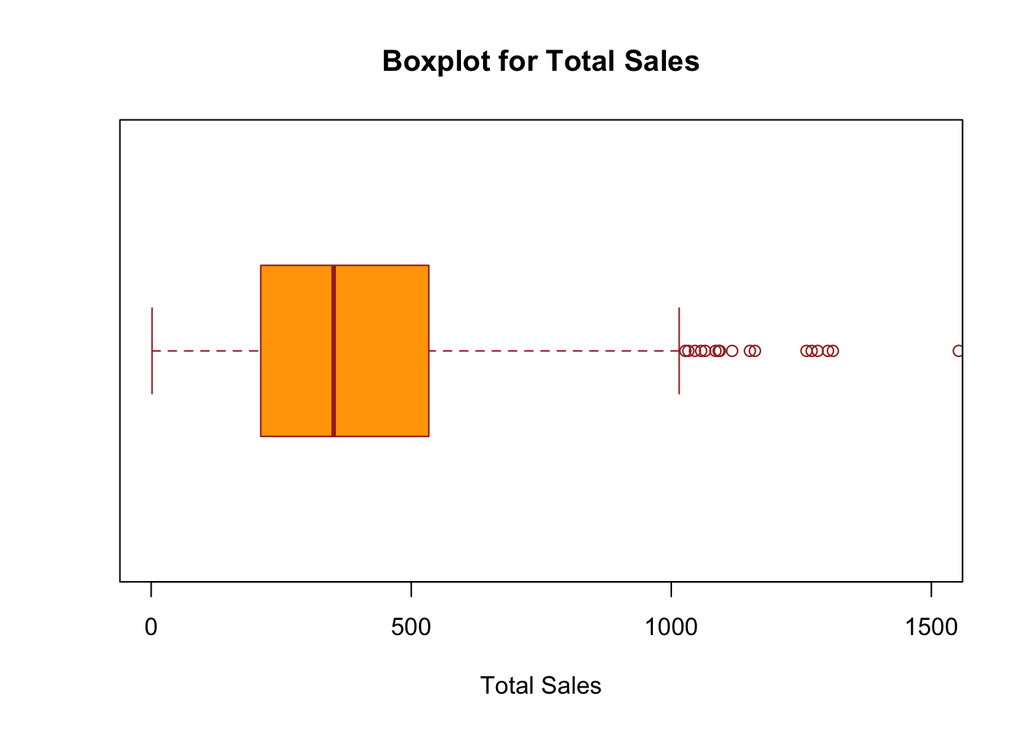

```r
boxplot(GobalSales$Sales,main = "Boxplot for Total Sales",
        xlab= "Total Sales",
        col="ORANGE",
        border = "brown",
        breaks=10,
        ylim = c(0,1500),
        horizontal = TRUE,ylab=NA)
```

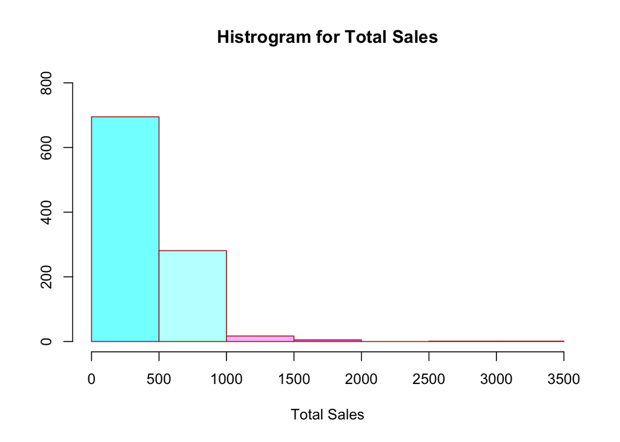

```r
hist(GobalSales$Sales,main = "Histrogram for Total Sales",
        xlab= "Total Sales",
        col=cm.colors(4),
        border = "brown",
        breaks=10,
        ylim = c(0,800),
        ylab=NA)
```

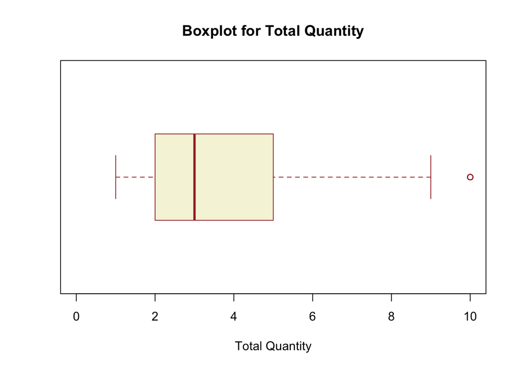

```r
boxplot(GobalSales$Quantity,main = "Boxplot for Total Quantity",
        xlab= "Total Quantity",
        col="beige",
        border = "brown",
        breaks=10,
        ylim = c(0,10),
        horizontal = TRUE,ylab=NA)
```

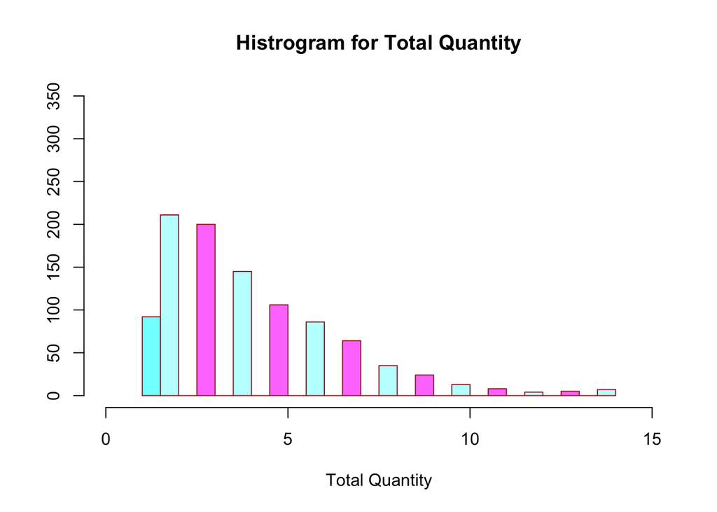

```r
hist(GobalSales$Quantity,main = "Histrogram for Total Quantity",
        xlab= "Total Quantity",
        col=cm.colors(4),
        border = "brown",
        breaks=20,
        ylim = c(0,350),
     xlim = c(0,15),
        ylab=NA)
```

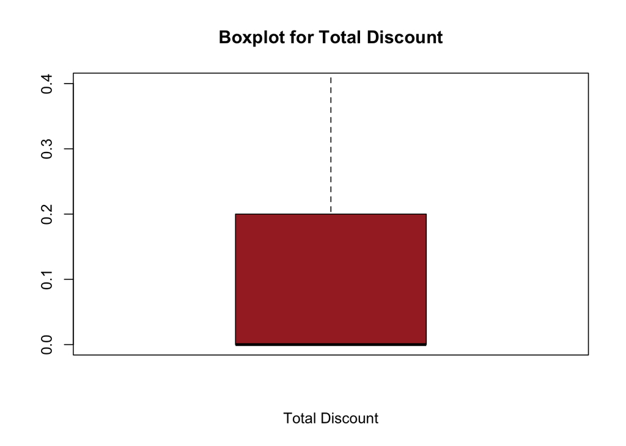

```r
boxplot(GobalSales$Discount,main = "Boxplot for Total Discount",
        xlab= "Total Discount",
        col="brown",
        border = "black",
        ylim = c(0,0.4),
        ylab=NA)
```

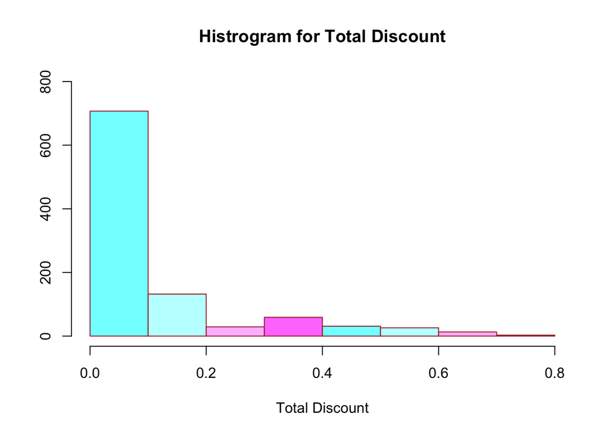

```r
hist(GobalSales$Discount,main = "Histrogram for Total Discount",
        xlab= "Total Discount",
        col=cm.colors(4),
        border = "brown",
        breaks= c(10),
        xlim = c(0,0.8),
        ylim = c(0,800),
        ylab=NA)
```

[figure not shown]

```r
hist(GobalSales$Quantity,main = "Histrogram for Total Profit",
        xlab= "Total Profit",
        col=rainbow(8),
        border = "brown",
     breaks=10,
        ylim = c(0,400),
        ylab=NA)
```

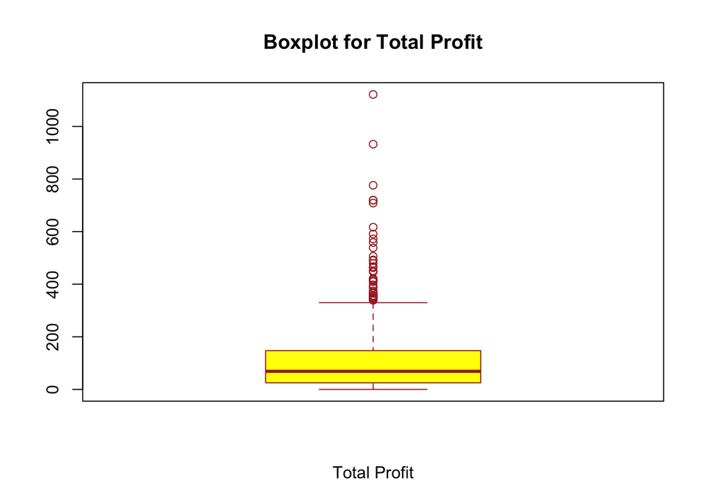

```r
boxplot(GobalSales$Profit,main = "Boxplot for Total Profit",
        xlab= "Total Profit",
        col="yellow",
        border = "brown",
     breaks=10,
     Ylim = c(0, 1300))
```

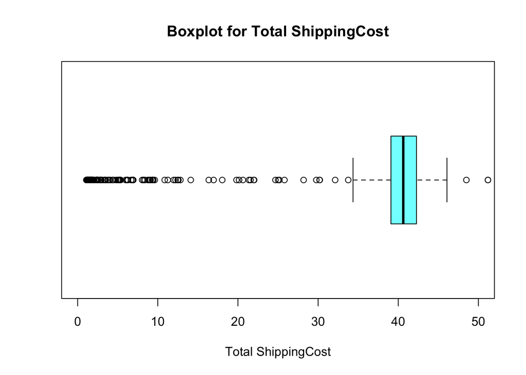

```r
boxplot(GobalSales$ShippingCost,main = "Boxplot for Total ShippingCost",
        xlab= "Total ShippingCost",
        col=cm.colors(8),
     breaks=5,
     horizontal = TRUE,
     ylim = c(0,50))
```

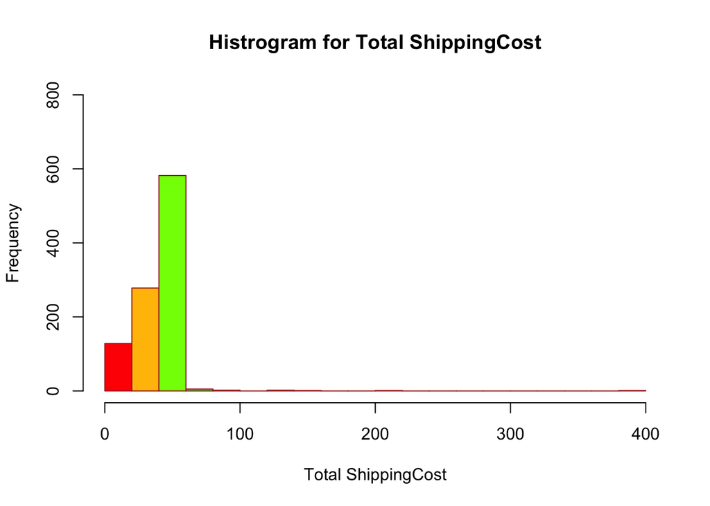

```r
hist(GobalSales$ShippingCost,main = "Histrogram for Total ShippingCost",
        xlab= "Total ShippingCost",
        col=rainbow(8),
        border = "brown",
     breaks= c(20),
     xlim = c(0,400),
        ylim = c(0,800))
```

# **Task 4. Counting of categorical variables groups**

```r
test = table(GobalSales$Market)
print(test)
```

```
##
##       Africa Asia Pacific       Europe        LATAM         USCA
##           62          302          261          205          170
```

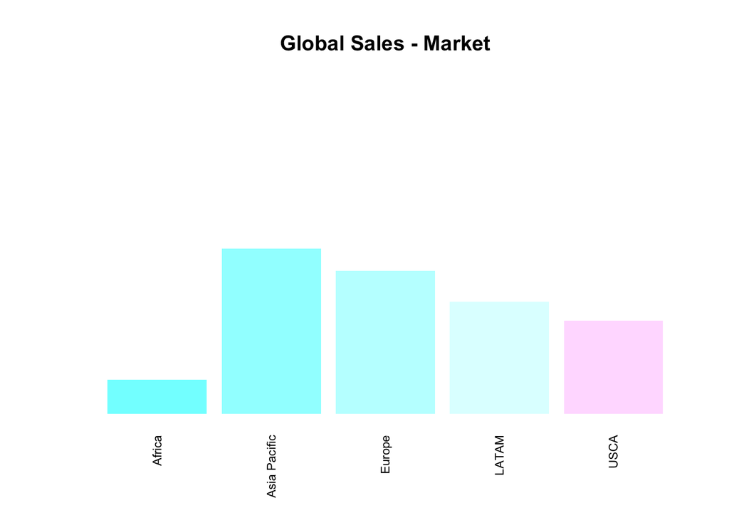

```r
barplot(test, main="Global Sales - Market",width= 1,
        space=0.15,
        border= NA,
        axes=F,
        las=2,
        cex.names=0.7,
        ylim = c(0,600),
        col=cm.colors(8))
```

```r
test = table(GobalSales$Category)
print(test)
```

```
##
##       Furniture Office Supplies      Technology
##             309             336             355
```

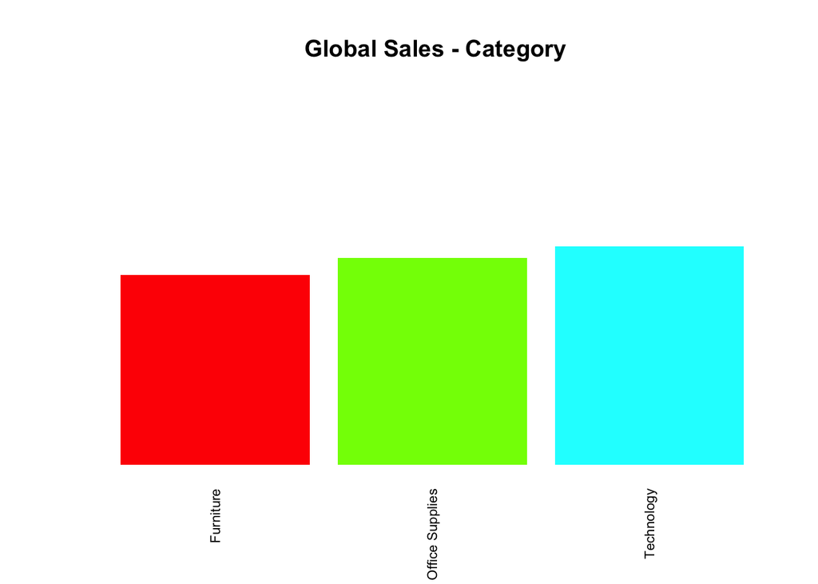

```r
barplot(test, main=" Global Sales - Category",width= 1,
        space=0.15,
        border= NA,
        axes=F,
        las=2,
        cex.names=0.7,
        ylim = c(0,600),
        col=rainbow(4))
```

```r
test = table(GobalSales$OrderPriority)
print(test)
```

```
##
## Critical     High      Low   Medium
##      105      342       45      508
```

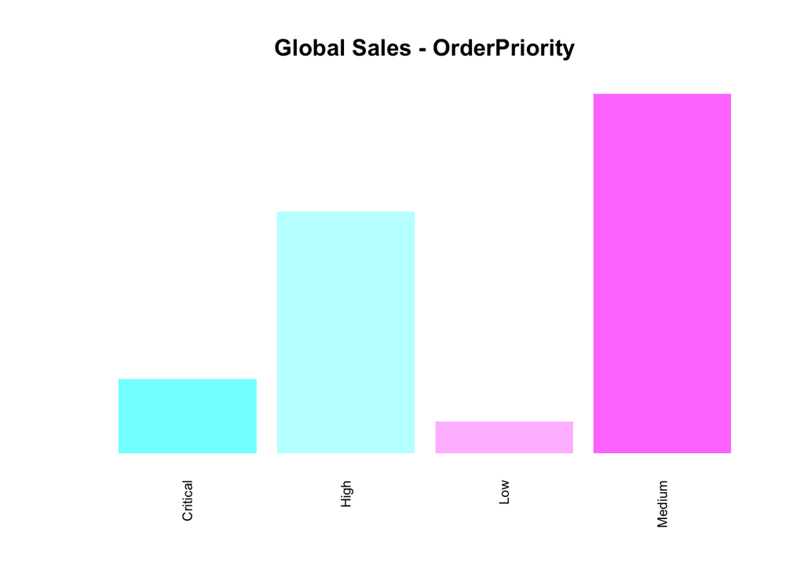

```r
barplot(test, main="Global Sales - OrderPriority",
        width= 1,
        space=0.15,
        border= NA,
        axes=F,
        las=2,
        cex.names=0.7,
        col=cm.colors(4))
```

**Global Sales- OrderPriority Result:** The global sales as per Order Priority suggests that there are least number of Low priority products to be delivered followed by Critical, High, and Medium priority.

# **Task 5**

**1. What is the median sales for the category market?**

```r
Market <- tapply(GobalSales$Sales,GobalSales$Market, median)
print(Market)
```

```
##       Africa Asia Pacific       Europe        LATAM         USCA
##       327.18       408.33       411.93       378.92        46.90
```

```r
Market1 <- table(GobalSales$Market)
Marketdf <- data.frame(Market1,Market)
colnames(Marketdf) <- c("Market", "Sales")
Marketdf
```

```
##                    Market Sales     NA
## Africa             Africa    62 327.18
## Asia Pacific Asia Pacific   302 408.33
## Europe             Europe   261 411.93
## LATAM               LATAM   205 378.92
## USCA                 USCA   170  46.90
```

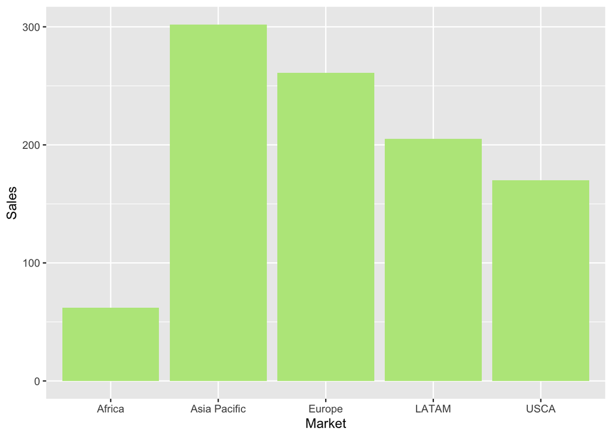

```r
ggplot(Marketdf, aes(x=Sales, y=Market)) +
  geom_bar(stat="identity", fill="#b9e68a") +
  coord_flip()
```

**2. What is the mean Profit for the categorical variables ShipMode?**

```r
ShipMode <- tapply(GobalSales$Profit,GobalSales$ShipMode, mean)
print(ShipMode)
```

```
##    First Class       Same Day   Second Class Standard Class
##       73.88873       67.49922       98.93794      120.14367
```

```r
ShipMode1 <- table(GobalSales$ShipMode)
ShipModedf <- data.frame(ShipMode1,ShipMode)
colnames(ShipModedf) <- c("ShipMode", "Profit")

ShipModedf
```

```
##                      ShipMode Profit        NA
## First Class       First Class    181  73.88873
## Same Day             Same Day     64  67.49922
## Second Class     Second Class    204  98.93794
## Standard Class Standard Class    551 120.14367
```

[figure not shown]

```r
ggplot(ShipModedf, aes(x=ShipMode, y=Profit)) +
  geom_bar(stat="identity", fill="brown") +
  coord_flip()
```

**Observation:** The mean profit for category shipping mode suggests that most products are ordered with Standard Class delivery, and products with same day delivery are the least.

**3. What is the mean Quantity for the categorical variables Category?**

```r
Category <- tapply(GobalSales$Quantity, GobalSales$Category, mean)
print(Category)
```

```
##       Furniture Office Supplies      Technology
##        3.964401        4.702381        3.684507
```

```r
Category1 <- table(GobalSales$Category)
Categorydf <- data.frame(Category1,Category)
colnames(Categorydf) <- c("Category", "Quantity")

Categorydf
```

```
##                        Category Quantity       NA
## Furniture             Furniture      309 3.964401
## Office Supplies Office Supplies      336 4.702381
## Technology           Technology      355 3.684507
```

[figure not shown]

```r
ggplot(Categorydf, aes(x=Category, y=Quantity)) +
  geom_bar(stat="identity", fill="#d4a9ce") +
  coord_flip()
```

# **Task 6**

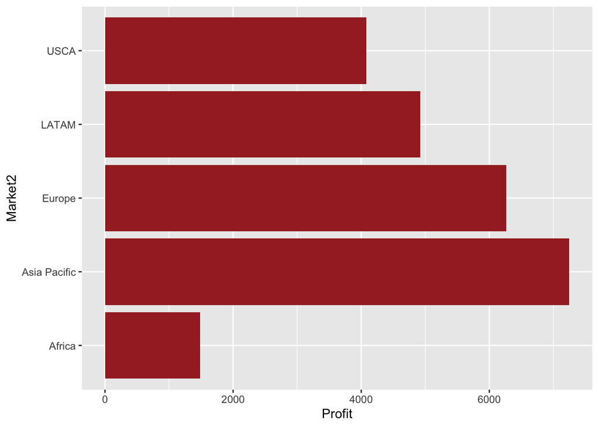

```r
Profit_Category <- GobalSales[GobalSales$Category %in% c("Technology"), ]
Same_Day_Profit <- Profit_Category[Profit_Category$ShipMode %in% c("Same Day"), ]
Same_Day_profit_Technology <- tapply(Same_Day_Profit$Profit, Same_Day_Profit$ShipMode, median)
Market2 <- GobalSales$Market
Category1 <- table(Same_Day_Profit$ShipMode)
Categorydf <- data.frame(Category1,Market2)
colnames(Categorydf) <- c("Market", "Profit")
ggplot(Categorydf, aes(x=Market2, y=Profit)) +
  geom_bar(stat="identity", fill = "BROWN") +
  coord_flip()
```

**PART 3. Conclusion, References, and Appendix Sections**

**BIBLIOGRAPHY**  
**References:**  
1) Allan B(2015)- Elementary statistics,edition 7). Retrieved January 19th 2018, from https://bmalone.weebly.com/uploads/2/2/3/9/22391186/bluman_statistics_book.pdf/  
2)Andrew A,(2019). Here’s How Data And Analytics Can Benefit E-Commerce Business Owners. Retrieved Jan 4, 2019, from https://www.forbes.com/sites/andrewarnold/2019/01/04/heres-how-data-and-analytics-can-benefit-e-commerce-business-owners/?sh=2d58dc911460/  
3) Jerry U, (2015). The Atlantic. Retrieved Mar 29,2015, from https://www.theatlantic.com/magazine/archive/2017/05/how-online-shopping-makes-suckers-of-us-all/521448/  
4) Joel M, (2017). ONLINE REVIEWS AND SEO, from Jan 26, 2017 From https://www.konstructdigital.com/seo/online-reviews-seo/

**APPENDIX**

Rmd file is included in this report.